# 10_Load_Data

# What affects the number of daily flights?

First, load in important libraries

```r
library(tidyverse)
library(janitor)
library(lubridate)
library(modelr)
```

## Load in flights and related data

Using Import Dataset > from text (readr) > Fix data units > unchoose open view > copy code > cancel > copy > Code / reformat code > code / reindent lines

```r
library(readr)
flights <-
  read_csv(
    "Data/flights.csv",
    col_types = cols(
      air_time = col_integer(),
      arr_delay = col_integer(),
      arr_time = col_integer(),
      day = col_integer(),
      dep_delay = col_integer(),
      dep_time = col_integer(),
      distance = col_integer(),
      flight = col_character(),
      hour = col_integer(),
      minute = col_integer(),
      month = col_integer(),
      sched_arr_time = col_integer(),
      sched_dep_time = col_integer(),
      year = col_integer()
    )
  )
```

## What is the flight volume by day?

There is no well-formatted data time filed for the departures. I will need to create a new column to be used throughout the analysis which mutates the current encoding.

```r
daily <- flights %>%
  mutate(date = make_date(year, month, day)) %>%
  group_by(date) %>%
  summarize (n = n()) %>%
  arrange(desc(n))
daily
```

| date | n |
| --- | --- |
| 2013-11-27 | 1014 |
| 2013-07-11 | 1006 |
| 2013-07-08 | 1004 |
| 2013-07-10 | 1004 |
| 2013-12-02 | 1004 |
| 2013-07-18 | 1003 |
| 2013-07-25 | 1003 |
| 2013-07-12 | 1002 |
| 2013-07-09 | 1001 |
| 2013-07-17 | 1001 |

[output cut: 355 more lines]

Busiest day was the day before Thanksgiving

```r
daily <- flights %>%
  mutate(date = make_date(year, month, day)) %>%
  group_by(date) %>%
  summarize (n = n()) %>%
  arrange(n)
daily
```

| date | n |
| --- | --- |
| 2013-11-28 | 634 |
| 2013-11-29 | 661 |
| 2013-01-19 | 674 |
| 2013-10-12 | 676 |
| 2013-01-26 | 680 |
| 2013-08-31 | 680 |
| 2013-02-02 | 682 |
| 2013-09-28 | 682 |
| 2013-02-09 | 684 |
| 2013-10-19 | 684 |

[output cut: 355 more lines]

Least travelled day was the day of Thanksgiving.

Let’s graph the time series of the number of flights.

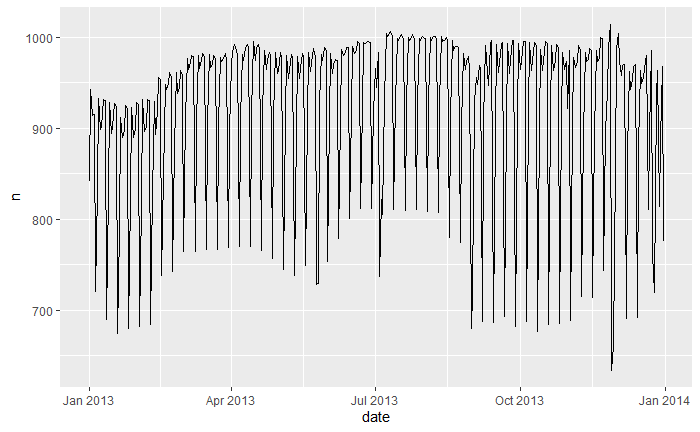

```r
ggplot (data = daily) +
  geom_line(mapping = aes (x = date, y = n))
```

Or

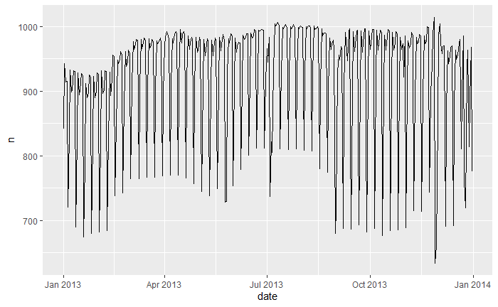

```r
daily %>%
  ggplot(mapping = aes(x = date, y = n)) +
  geom_line()
```

Spikes, drops in volume might be day of week

We need an analysis of the distribution of flights by the day of week.

We need to indicate day of week in dataframe.

```r
daily <- daily %>%
  mutate(wday = wday(date, label = TRUE))
```

Plot distribution of flights by day of the week

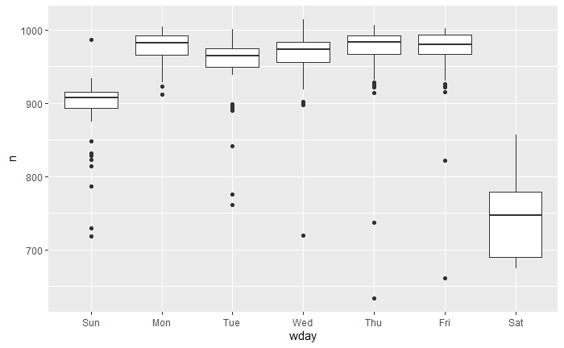

```r
daily %>%
  ggplot(mapping = aes (wday, n)) +
  geom_boxplot()
```

Remove the effect of the day of week. I will fit a linear regression model and graph the residuals.

Lm is linear model (fit n based on the day of the week)

```r
mod <- lm(n ~ wday, data = daily)
daily <- daily %>%
  add_residuals(mod)
```

Now plot the residuals.

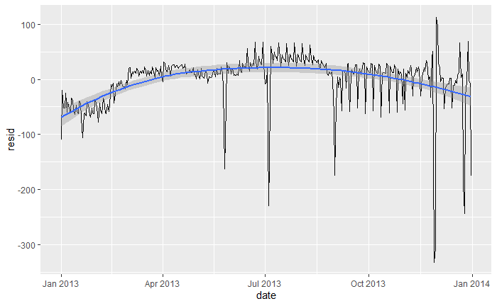

```r
daily %>%
  ggplot (mapping = aes (date, resid)) +
  geom_line() +
  geom_smooth()
```